# Лабораторная работа №6

Поиск файлов. Перенаправление ввода-вывода. Просмотр запущенных процессов

Мулин И.

Российский университет дружбы народов, Москва, Россия

9 марта 2023

# Информация

## Докладчик

- Мулин Иван Владимирович
- студент
- студент-первокурсник
- Математический институт им. Никольского
- https://github.com/ivmulin

# Вводная часть

## Актуальность

- Умение взаимодействовать с файловой системой обязательно для владения компьютером.

## Цели и задачи

Цель работы - изучить инструменты по работе поиском файлов и фильтрацией тесктовых данных, а также по управлению процессами и анализом монтированных дисков.

# Выполнение лабораторной работы

## Перенаправление ввода-вывода

Вывели содержимое каталога `~/bin` в файл `file.txt`:

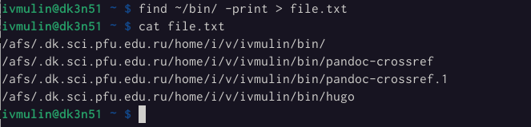

Поиск нужных файлов

При помощи команды `grep` нашли файлы, имеющие в названни шаблон *cross*, и вывели результат в файл `conf.txt`:

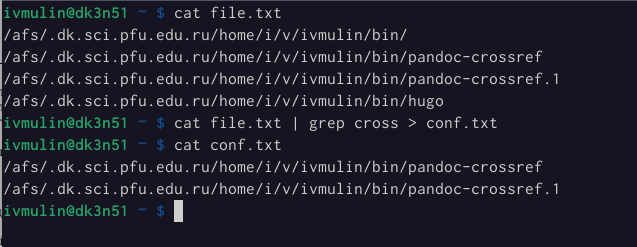

Поиск нужных по шаблону

## Перенаправление ввода-вывода

(Вывести файлы в домашнем каталоге, начинающиеся с символа *c*, можно при помощи команды `find ~ -name "c*" -print`.)

Далее вывели постранично все файлы каталога `/etc`, что начинаются с симовла *h*:

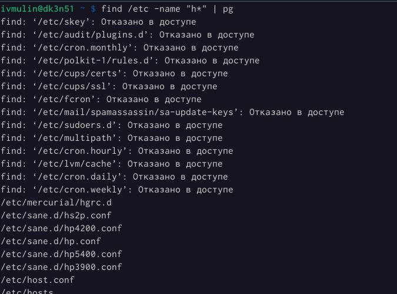

Постраничный вывод найденных файлов

## Управление процессами

В фоновом режиме запустили процесс, записывающий в файл `~/logfile` все начинающиеся с *log* файлы:

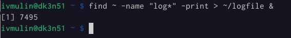

Запуск фнового процесса

## Управление процессами

Тут же удалили буквально только что созданный нами файл:

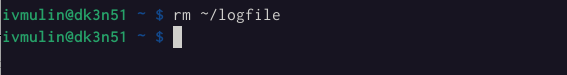

Удаление детища

## Управление процессами

Запустили в терминале фоновый процесс `gedit`:

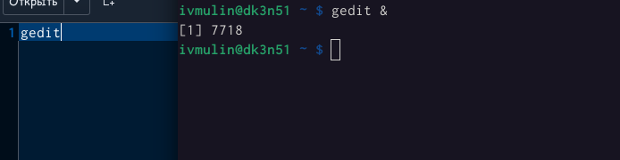

Запуск `gedit` в фоновом режиме

## Управление процессами

Используя команду `kill`, уничтожили созданный процесс:

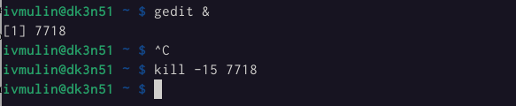

Удаление процесса

## Проверка использования диска

Запустили утилиту `du`:

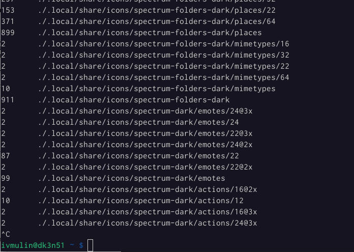

`du`

## Проверка использования диска

Запустили команду `df`:

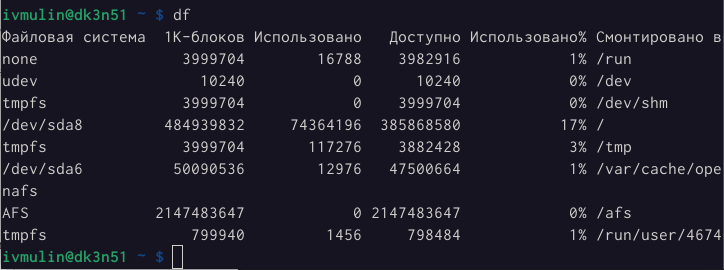

`df`

## Проверка использования диска

При помощи команды `find ~ -type d` вывели в консоль азвание всех директорий домашнего каталога:

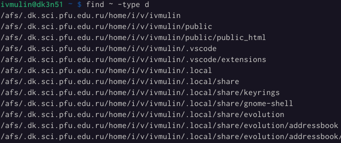

Поиск директорий

## Ответы на контрольные вопросы

1. Какие потоки ввода вывода вы знаете?

*Ответ*: `stdin`, `stdout`, `stderr`.

## Ответы на контрольные вопросы

2. Объясните разницу между операцией > и >>.

*Ответ*: *>* перенаправляет вывод в новый файл, *>>* перенаправляет вывод в файл, добавляя содержимое в конце.

## Ответы на контрольные вопросы

3. Что такое конвейер?

*Ответ*: [Конвейер](https://ru.wikipedia.org/wiki/%D0%9A%D0%BE%D0%BD%D0%B2%D0%B5%D0%B9%D0%B5%D1%80) (от англ. convey «передавать») — машина непрерывного транспорта, предназначенная для перемещения сыпучих, кусковых или штучных грузов. Часто также называется транспортёром.

## Конвейер

[figure not shown]

Конвейер

## Конвейер

[figure not shown]

Конвейер

4. Что такое процесс? Чем это понятие отличается от программы?

## Ответы на контрольные вопросы

*Ответ*: процесс — задача, выполняемая процессором; программа — команда для процессора.

## Ответы на контрольные вопросы

5. Что такое PID и GID?

*Ответ*: PID (process Id) — идентификатор процесса; GID — идентификатор группы.

## Ответы на контрольные вопросы

9. Можно ли по контексту (содержанию) найти файл? Если да, то как?

*Ответ*: можно использовать команду `grep "текст" каталог`.

## Ответы на контрольные вопросы

10. Как определить объем свободной памяти на жёстком диске?

*Ответ*: команда `df` показывает искомое.

## Ответы на контрольные вопросы

11. Как определить объем вашего домашнего каталога?

*Ответ*: см. предыдущий вопрос; `df ~`.

## Ответы на контрольные вопросы

12. Как удалить зависший процесс?

*Ответ*: пусть зачто — название зависшего процесса. Тогда выполнить задачу можно при помощи команды `kill -15 "$(pidof зачто)"`.

# Результаты

## Заключение

В ходе выполнения лабораторной работы были освоены инструменты по работе поиском файлов и фильтрацией тесктовых данных, а также по управлению процессами и анализом монтированных дисков. Значит, цель работы была достигнута.